# lab7_and_8

```python
import pickle
%matplotlib inline
import numpy as np
import matplotlib
import matplotlib.pyplot as plt
import scipy
from scipy import stats
import h5py
from scipy import stats
from scipy.stats import poisson
from scipy.stats import norm
import pandas
```

### Lab 7

```python
# open the file of interest, and use pickle loading
signal_file = open ("Sample_pt_250_500.pkl",'rb')
sample_dict = pickle.load(signal_file)

# list all keys of the files
sample_dict.keys()
```

```
Index(['pt', 'eta', 'phi', 'mass', 'ee2', 'ee3', 'd2', 'angularity', 't1',
       't2', 't3', 't21', 't32', 'KtDeltaR'],
      dtype='object')
```

```python
background_file = open ("qcd_100000_pt_250_500.pkl",'rb')
background_dict = pickle.load(background_file)
```

There are a total of 20100 events comprising of 100 higgs events and 20000 qcd events. So, we can weigh the data.

```python
n_higgs_norm = 100/20100
n_qcd_norm = 20000/20100
```

https://matplotlib.org/stable/api/_as_gen/matplotlib.pyplot.hist.html

Now, I will use these weights to plot the mass distributions.

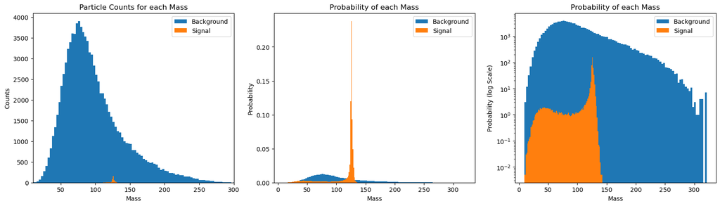

```python
fig,ax = plt.subplots(1,3,figsize=(20,5))
n_higgs_counts,bins1 = np.histogram(sample_dict['mass'],bins = 100)
n_qcd_counts,bins2 = np.histogram(background_dict['mass'],bins = 100)

ax[0].hist(bins2[:-1], bins2, weights=n_qcd_counts*n_qcd_norm,label="Background")
ax[0].hist(bins1[:-1], bins1, weights=n_higgs_counts*n_higgs_norm,label="Signal")
ax[0].set_xlim([10,300])
ax[0].set_title('Particle Counts for each Mass')
ax[0].set_xlabel('Mass')
ax[0].set_ylabel('Counts')
ax[0].legend(loc='best')

ax[1].hist(bins2[:-1], bins2, weights=n_qcd_counts*n_qcd_norm,density=True,label="Background")
ax[1].hist(bins1[:-1], bins1, weights=n_higgs_counts*n_higgs_norm,density=True,label="Signal")
ax[1].legend(loc='best')
ax[1].set_title('Probability of each Mass')
ax[1].set_xlabel('Mass')
ax[1].set_ylabel('Probability')

ax[2].hist(bins2[:-1], bins2, weights=n_qcd_counts*n_qcd_norm,label="Background")
ax[2].hist(bins1[:-1], bins1, weights=n_higgs_counts*n_higgs_norm,label="Signal")
ax[2].set_yscale('log')
ax[2].legend(loc='best')
ax[2].set_title('Probability of each Mass')
ax[2].set_xlabel('Mass')
ax[2].set_ylabel('Probability (log Scale)')

plt.show()
```

The plot above shows the whole data set with the higgs data shown with mean at ~115. Notice the peak of the higgs signal is at ~125 so this is where the most higgs signals are. i.e. the most likely mass of the higgs. The QCD data with mean ~97. The QCD data is, however, skewed a bit centered around mass of 70-75.

Now I will calculate the significance.

```python
n_higgs = 100
n_qcd = 20000
sigma = poisson.cdf(n_higgs + n_qcd,n_qcd)
probability = norm.isf(1-sigma)
probability
```

```
0.7112259282313185
```

Now let's see how this approximation compares to the data.

```python
approx = n_higgs/np.sqrt(n_qcd)
approx
```

```
0.7071067811865475
```

not equivalent, but pretty close. Although in particle physics, this approximation is not good enough. This approximation is a gaussian statistic and gives us a good idea about what the probability value is. As an estimate, I will continue to use this approximation in the rest of the significance calculations.

Now, I will make some mass cuts to find the the best significance

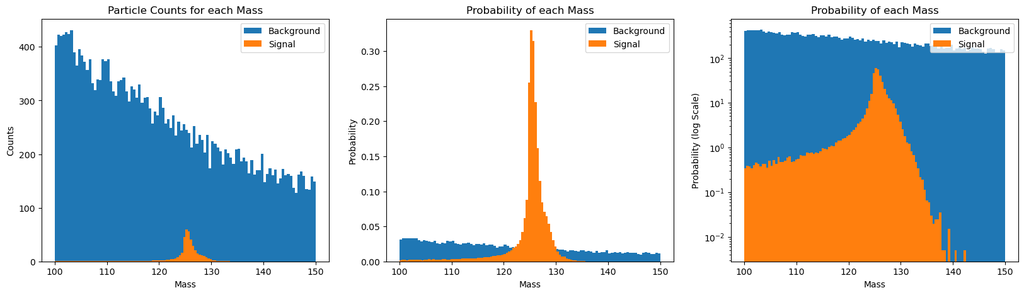

```python
n_higgs_norm = 100/20100
n_qcd_norm = 20000/20100
def cut(sample_data,background_data,higgs_low_bound,higgs_high_bound,bkd_low_bound,bkd_high_bound,feature):
    cut_mass_higgs = sample_data[sample_data[feature]>higgs_low_bound]
    cut_mass_qcd = background_data[background_data[feature]>bkd_low_bound]

    cut_mass_higgs = cut_mass_higgs[cut_mass_higgs[feature]<higgs_high_bound]
    cut_mass_qcd = cut_mass_qcd[cut_mass_qcd[feature]<bkd_high_bound]

    fig,ax = plt.subplots(1,3,figsize=(20,5))
    n_higgs_counts,bins1 = np.histogram(cut_mass_higgs[feature],bins = 100)
    n_qcd_counts,bins2 = np.histogram(cut_mass_qcd[feature],bins = 100)

    ax[0].hist(bins2[:-1], bins2, weights=n_qcd_counts*n_qcd_norm,label="Background")
    ax[0].hist(bins1[:-1], bins1, weights=n_higgs_counts*n_higgs_norm,label="Signal")
    ax[0].set_title('Particle Counts for each Mass')
    ax[0].set_xlabel('Mass')
    ax[0].set_ylabel('Counts')
    ax[0].legend(loc='best')

    ax[1].hist(bins2[:-1], bins2, weights=n_qcd_counts*n_qcd_norm,density=True,label="Background")
    ax[1].hist(bins1[:-1], bins1, weights=n_higgs_counts*n_higgs_norm,density=True,label="Signal")
    ax[1].legend(loc='best')
    ax[1].set_title('Probability of each Mass')
    ax[1].set_xlabel('Mass')
    ax[1].set_ylabel('Probability')

    ax[2].hist(bins2[:-1], bins2, weights=n_qcd_counts*n_qcd_norm,label="Background")
    ax[2].hist(bins1[:-1], bins1, weights=n_higgs_counts*n_higgs_norm,label="Signal")
    ax[2].set_yscale('log')
    ax[2].legend(loc='best')
    ax[2].set_title('Probability of each Mass')
    ax[2].set_xlabel('Mass')
    ax[2].set_ylabel('Probability (log Scale)')

    plt.show()
    return cut_mass_higgs, cut_mass_qcd

cut_mass_higgs, cut_mass_qcd = cut(sample_dict,background_dict,100,150,100,150,'mass')
```

```python
def signif(cut_mass_higgs,cut_mass_qcd,feature):
    n_higgs = 100
    n_qcd = 20000
    higgs = (sum(cut_mass_higgs[feature]) / sum(sample_dict[feature])) * n_higgs
    qcd = (sum(cut_mass_qcd[feature]) / sum(background_dict[feature])) * n_qcd

    significance = higgs / np.sqrt(qcd)
    print(significance)
```

```python
signif(cut_mass_higgs,cut_mass_qcd,'mass')
```

```
1.1556144516115936
```

Need to find cuts to increase this number

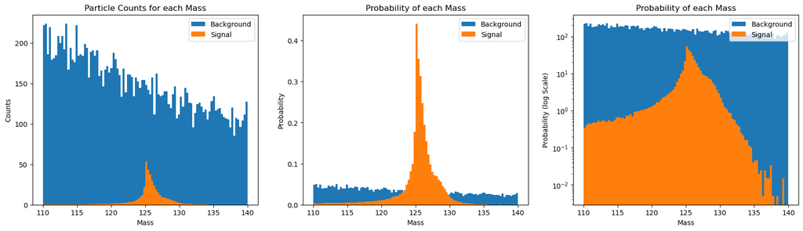

```
1.464999846258688
```

```python
cut_mass_higgs, cut_mass_qcd = cut(sample_dict,background_dict,110,140,110,140,'mass')
signif(cut_mass_higgs,cut_mass_qcd,'mass')
```

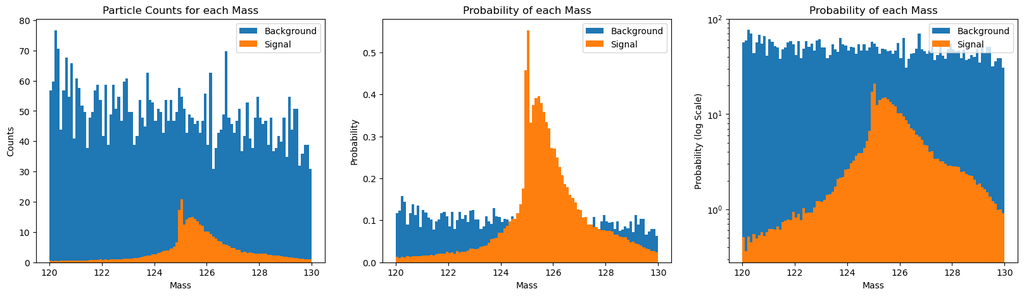

```
2.3470782626118902
```

```python
cut_mass_higgs, cut_mass_qcd = cut(sample_dict,background_dict,120,130,120,130,'mass')
signif(cut_mass_higgs,cut_mass_qcd,'mass')
```

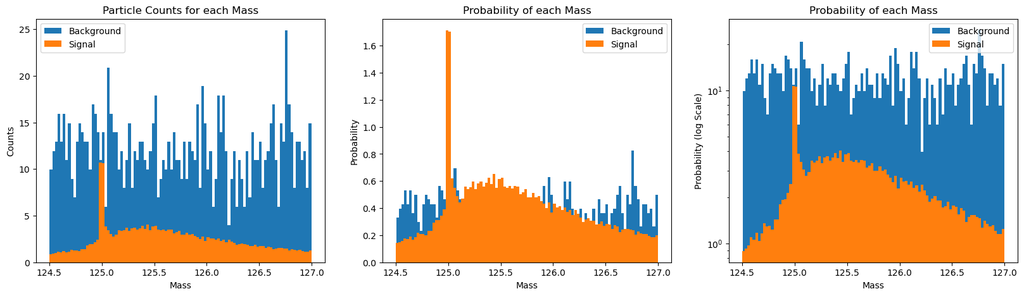

```
3.1007590939315057
```

```python
cut_mass_higgs, cut_mass_qcd = cut(sample_dict,background_dict,124.5,127,124.5,127,'mass')
signif(cut_mass_higgs,cut_mass_qcd,'mass')
```

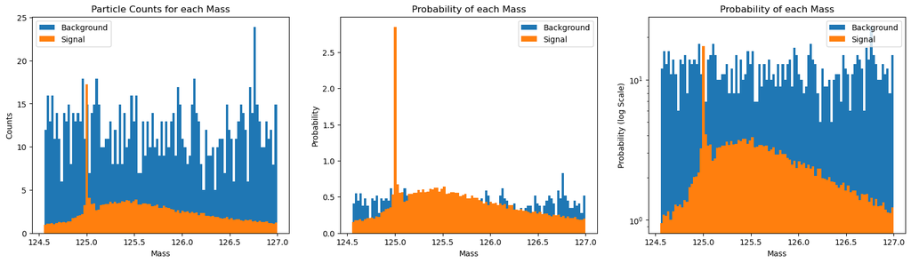

```
3.1065303151335293
```

```python
cut_mass_higgs, cut_mass_qcd = cut(sample_dict,background_dict,124.55,127,124.55,127,'mass')
signif(cut_mass_higgs,cut_mass_qcd,'mass')
```

We see that the optimal mass cuts are at 124.55 and 127 so we can use this interval on the rest of the parameters to get the highest significance value possible. The highest significance I was able to achieve is about 3.107. This is the point where there are the most higgs signals compared to QCD.

### Rest of Features

Set A: First, I will plot the rest of the features to identify the most discriminative parameters and the cut intervals.

```python
def hist(feature,sample_data,background_data):
    fig,ax = plt.subplots(1,3,figsize=(20,5))
    n_higgs_counts,bins1 = np.histogram(sample_data[feature],bins = 100)
    n_qcd_counts,bins2 = np.histogram(background_data[feature],bins = 100)

    ax[0].hist(bins2[:-1], bins2, weights=n_qcd_counts*n_qcd_norm,label="Background")
    ax[0].hist(bins1[:-1], bins1, weights=n_higgs_counts*n_higgs_norm,label="Higgs Signal")
    ax[0].set_title(feature)
    ax[0].set_title('Particle Counts for each ' + feature)
    ax[0].set_xlabel(feature)
    ax[0].set_ylabel('Counts')
    ax[0].legend(loc='best')

    ax[1].hist(bins2[:-1], bins2, weights=n_qcd_counts*n_qcd_norm,density=True,label="Background")
    ax[1].hist(bins1[:-1], bins1, weights=n_higgs_counts*n_higgs_norm,density=True,label="Higgs Signal")
    ax[1].set_title(feature)
    ax[1].legend(loc='best')
    ax[1].set_xlabel(feature)
    ax[1].set_ylabel('Probability')
    ax[1].set_title('Probability of each ' + feature + ' value')

    ax[2].hist(bins2[:-1], bins2, weights=n_qcd_counts*n_qcd_norm,label="Background")
    ax[2].hist(bins1[:-1], bins1, weights=n_higgs_counts*n_higgs_norm,label="Higgs Signal")
    ax[2].set_yscale('log')
    ax[2].set_ylabel('Probability (log scale)')
    ax[2].legend(loc='best')
    ax[2].set_title('Probability of each ' + feature + ' value')
    ax[2].set_xlabel(feature)

    plt.show()
```

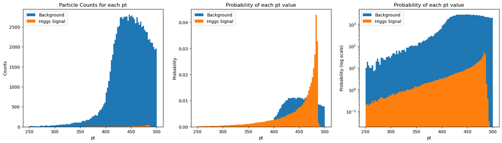

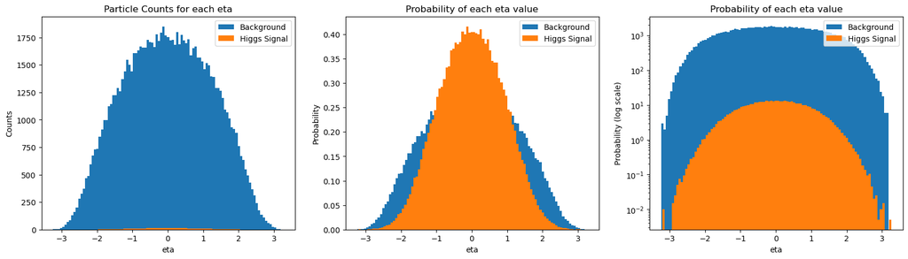

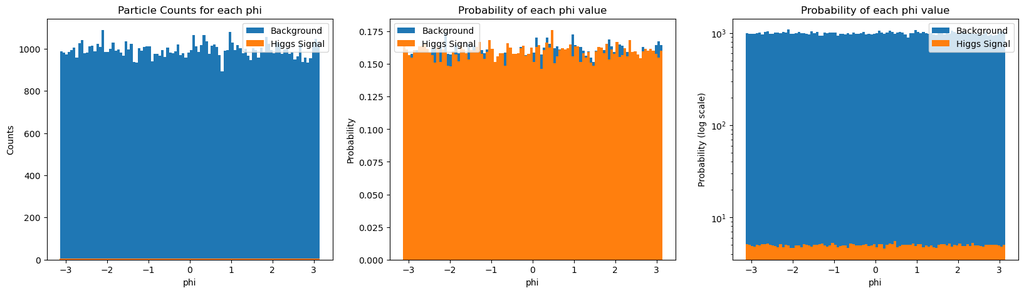

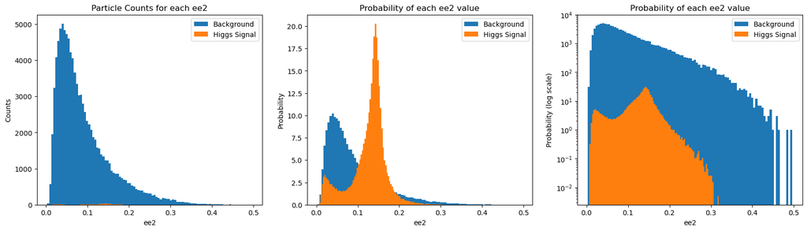

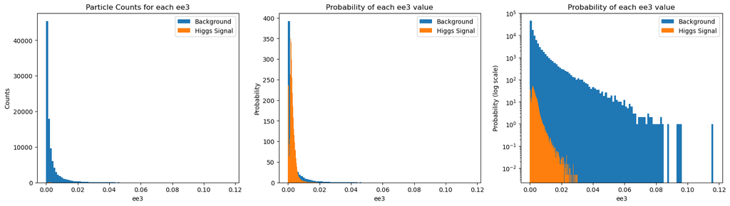

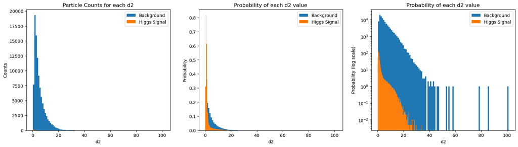

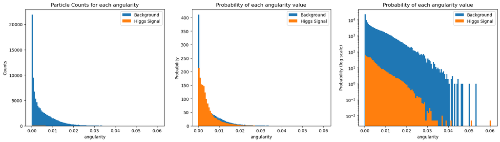

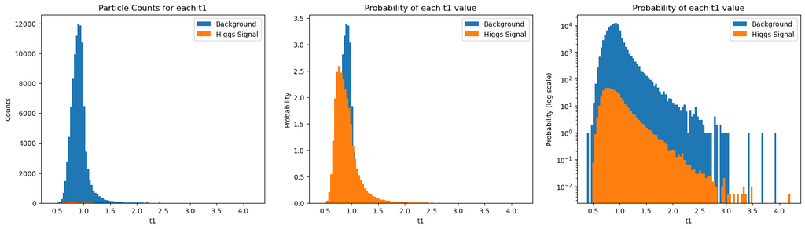

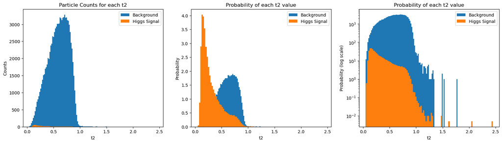

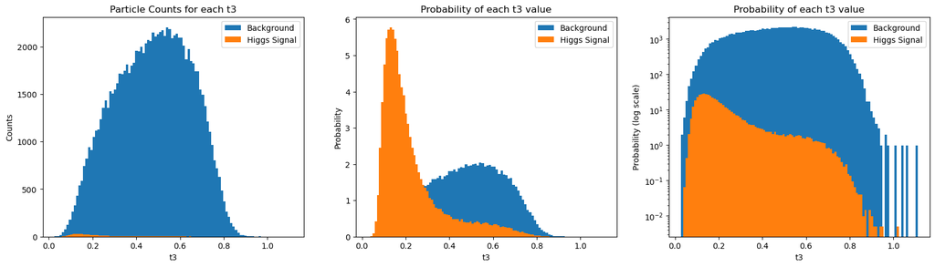

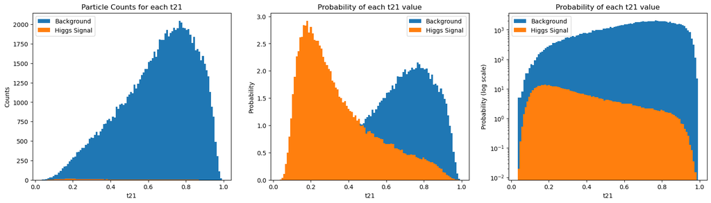

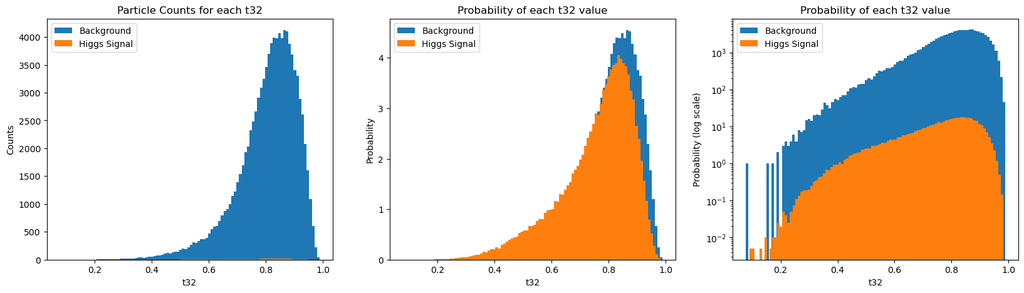

[1 more figures not shown]

```python
#WITHOUT EVENT SELECTION
parameters = ['pt','eta','phi','ee2','ee3','d2','angularity','t1','t2','t3','t21','t32','KtDeltaR']
for i in parameters:
    hist(i,sample_dict,background_dict)
```

Looking at the other parameters, it is definately possible to make cuts to improve the significance. First lets try the transverse momentum

Set B:

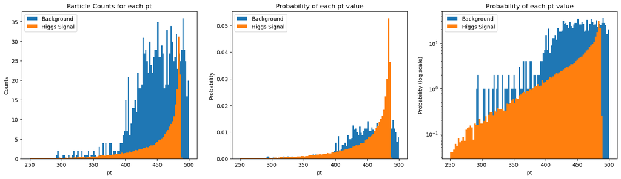

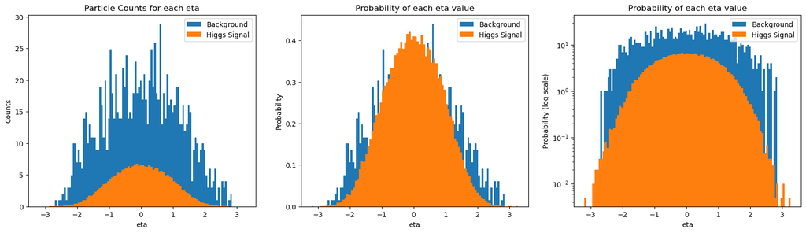

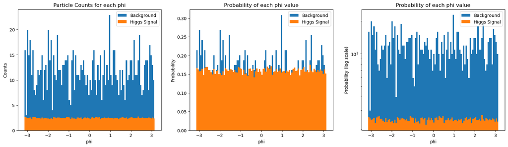

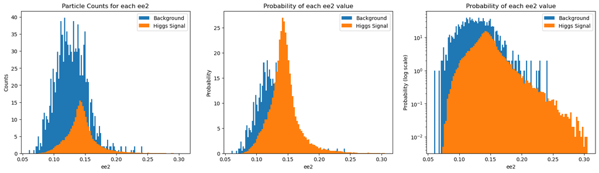

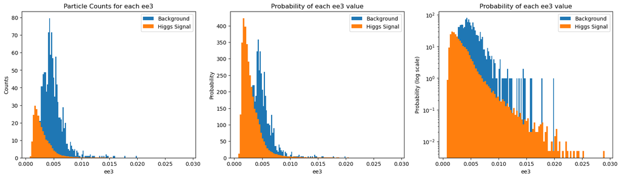

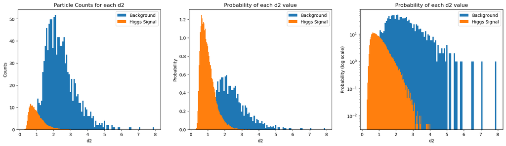

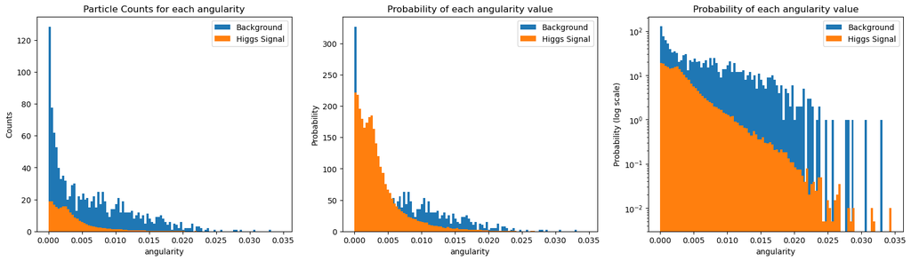

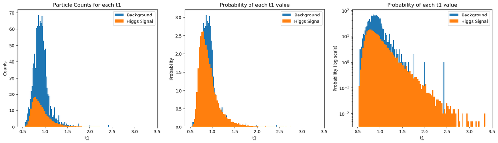

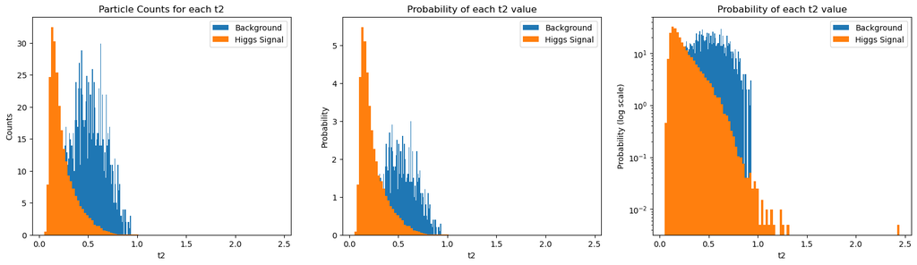

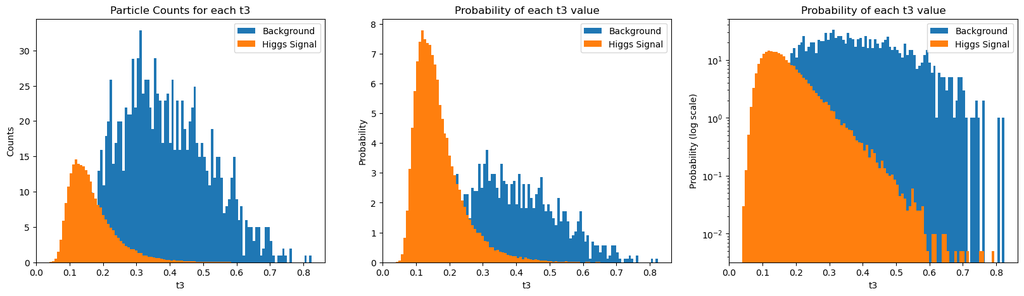

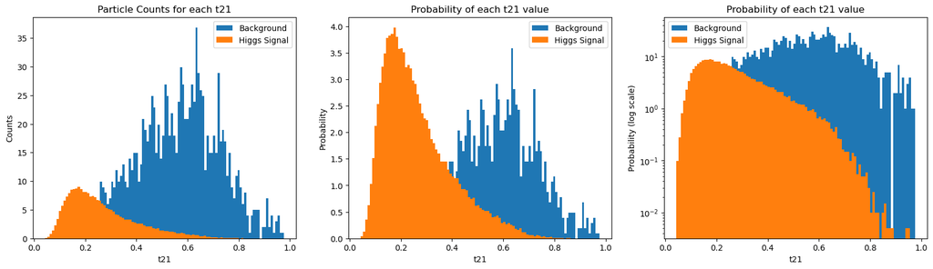

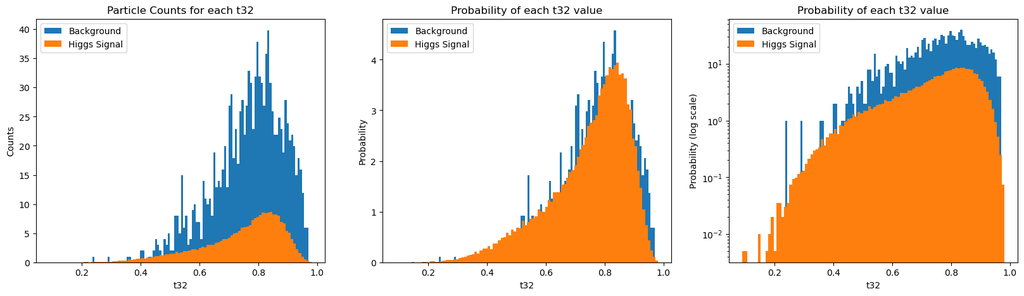

[1 more figures not shown]

```python
#WITH OPTIMIZED MASS CUTS
for i in parameters:
    hist(i,cut_mass_higgs,cut_mass_qcd)
```

It is possible to make cuts on ee2, ee3, d2, angularity, t2, t3, t21, ktDeltaR. First, I will make cuts on t21 as it is the most discrimative.

```python
n_higgs_norm = 100/20100
n_qcd_norm = 20000/20100
def cut1(sample_data,background_data,higgs_low_bound,higgs_high_bound,bkd_low_bound,bkd_high_bound,feature):

    cut_higgs = sample_data[sample_data[feature]>higgs_low_bound]       #low bound
    cut_qcd = background_data[background_data[feature]>bkd_low_bound]

    cut_higgs = cut_higgs[cut_higgs[feature]<higgs_high_bound]      #high bound
    cut_qcd = cut_qcd[cut_qcd[feature]<bkd_high_bound]

    fig,ax = plt.subplots(1,3,figsize=(20,5))
    n_higgs_counts,bins1 = np.histogram(cut_higgs[feature],bins = 100)
    n_qcd_counts,bins2 = np.histogram(cut_qcd[feature],bins = 100)

    ax[0].hist(bins2[:-1], bins2, weights=n_qcd_counts*n_qcd_norm,label="Background")
    ax[0].hist(bins1[:-1], bins1, weights=n_higgs_counts*n_higgs_norm,label="Higgs Signal")
    ax[0].set_title(feature)
    ax[0].set_title('Particle Counts for each ' + feature)
    ax[0].set_xlabel(feature)
    ax[0].set_ylabel('Counts')
    ax[0].legend(loc='best')

    ax[1].hist(bins2[:-1], bins2, weights=n_qcd_counts*n_qcd_norm,density=True,label="Background")
    ax[1].hist(bins1[:-1], bins1, weights=n_higgs_counts*n_higgs_norm,density=True,label="Higgs Signal")
    ax[1].set_title(feature)
    ax[1].legend(loc='best')
    ax[1].set_xlabel(feature)
    ax[1].set_ylabel('Probability')
    ax[1].set_title('Probability of each ' + feature + ' value')

    ax[2].hist(bins2[:-1], bins2, weights=n_qcd_counts*n_qcd_norm,label="Background")
    ax[2].hist(bins1[:-1], bins1, weights=n_higgs_counts*n_higgs_norm,label="Higgs Signal")
    ax[2].set_yscale('log')
    ax[2].set_ylabel('Probability (log scale)')
    ax[2].legend(loc='best')
    ax[2].set_title('Probability of each ' + feature + ' value')
    ax[2].set_xlabel(feature)

    plt.show()
    return cut_higgs, cut_qcd
```